# TSK_INN_Learner_Notebook_Full_code

### Neural Network with Balanced Data (by applying SMOTE), Adam Optimizer, and Dropout

```python
# clears the current Keras session, resetting all layers and models previously created, freeing up memory and resources.
tf.keras.backend.clear_session()
```

```python
# defining the dropout ratio
# 20% of the neurons will be switched off
dropout_rate = 0.2
```

```python
#Initializing the neural network
model6 = Sequential()
model6.add(Dense(128,activation="relu",input_dim=x_train.shape[1]))
model6.add(Dropout(dropout_rate))
model6.add(Dense(64,activation="relu"))
model6.add(Dropout(dropout_rate))
model6.add(Dense(1,activation="sigmoid"))
```

```python
model6.summary()
```

```
Model: "sequential"
```

```
┏━━━━━━━━━━━━━━━━━━━━━━━━━━━━━━━━━━━━━━┳━━━━━━━━━━━━━━━━━━━━━━━━━━━━━┳━━━━━━━━━━━━━━━━━┓
┃ Layer (type)                         ┃ Output Shape                ┃         Param # ┃
┡━━━━━━━━━━━━━━━━━━━━━━━━━━━━━━━━━━━━━━╇━━━━━━━━━━━━━━━━━━━━━━━━━━━━━╇━━━━━━━━━━━━━━━━━┩
│ dense (Dense)                        │ (None, 128)                 │           1,536 │
├──────────────────────────────────────┼─────────────────────────────┼─────────────────┤
│ dropout (Dropout)                    │ (None, 128)                 │               0 │
├──────────────────────────────────────┼─────────────────────────────┼─────────────────┤
│ dense_1 (Dense)                      │ (None, 64)                  │           8,256 │
├──────────────────────────────────────┼─────────────────────────────┼─────────────────┤
│ dropout_1 (Dropout)                  │ (None, 64)                  │               0 │
├──────────────────────────────────────┼─────────────────────────────┼─────────────────┤
│ dense_2 (Dense)                      │ (None, 1)                   │              65 │
└──────────────────────────────────────┴─────────────────────────────┴─────────────────┘
```

```
 Total params: 9,857 (38.50 KB)
```

```
 Trainable params: 9,857 (38.50 KB)
```

```
 Non-trainable params: 0 (0.00 B)
```

```python
optimizer = keras.optimizers.Adam()    # defining Adam as the optimizer to be used
model6.compile(loss="binary_crossentropy", optimizer=optimizer, metrics=metrics,run_eagerly=True)
```

```python
start = time.time()
history = model6.fit(x_train_over, y_train_over, validation_data=(x_val,y_val) , batch_size=batch_size, epochs=epochs)
end=time.time()
```

```
399/399 ━━━━━━━━━━━━━━━━━━━━ 17s 43ms/step - loss: 0.5799 - recall: 0.6790 - val_loss: 0.4507 - val_recall: 0.7598
399/399 ━━━━━━━━━━━━━━━━━━━━ 18s 44ms/step - loss: 0.4835 - recall: 0.7650 - val_loss: 0.4361 - val_recall: 0.7542
399/399 ━━━━━━━━━━━━━━━━━━━━ 20s 43ms/step - loss: 0.4643 - recall: 0.7595 - val_loss: 0.4236 - val_recall: 0.7374
399/399 ━━━━━━━━━━━━━━━━━━━━ 18s 45ms/step - loss: 0.4525 - recall: 0.7628 - val_loss: 0.4227 - val_recall: 0.7374
399/399 ━━━━━━━━━━━━━━━━━━━━ 20s 43ms/step - loss: 0.4483 - recall: 0.7800 - val_loss: 0.4196 - val_recall: 0.7318
399/399 ━━━━━━━━━━━━━━━━━━━━ 18s 44ms/step - loss: 0.4448 - recall: 0.7764 - val_loss: 0.4132 - val_recall: 0.7374
399/399 ━━━━━━━━━━━━━━━━━━━━ 21s 45ms/step - loss: 0.4380 - recall: 0.7731 - val_loss: 0.4090 - val_recall: 0.7318
399/399 ━━━━━━━━━━━━━━━━━━━━ 17s 43ms/step - loss: 0.4335 - recall: 0.7828 - val_loss: 0.4008 - val_recall: 0.7263
399/399 ━━━━━━━━━━━━━━━━━━━━ 18s 45ms/step - loss: 0.4243 - recall: 0.7891 - val_loss: 0.4142 - val_recall: 0.7318
399/399 ━━━━━━━━━━━━━━━━━━━━ 17s 42ms/step - loss: 0.4238 - recall: 0.7902 - val_loss: 0.4013 - val_recall: 0.7318
399/399 ━━━━━━━━━━━━━━━━━━━━ 21s 45ms/step - loss: 0.4154 - recall: 0.7963 - val_loss: 0.4033 - val_recall: 0.7318
399/399 ━━━━━━━━━━━━━━━━━━━━ 17s 44ms/step - loss: 0.4090 - recall: 0.7984 - val_loss: 0.4122 - val_recall: 0.7430
399/399 ━━━━━━━━━━━━━━━━━━━━ 20s 43ms/step - loss: 0.4086 - recall: 0.8123 - val_loss: 0.4120 - val_recall: 0.7374
399/399 ━━━━━━━━━━━━━━━━━━━━ 21s 44ms/step - loss: 0.4037 - recall: 0.8197 - val_loss: 0.4065 - val_recall: 0.7318
399/399 ━━━━━━━━━━━━━━━━━━━━ 21s 45ms/step - loss: 0.3994 - recall: 0.8118 - val_loss: 0.3946 - val_recall: 0.7263
399/399 ━━━━━━━━━━━━━━━━━━━━ 18s 44ms/step - loss: 0.3953 - recall: 0.8238 - val_loss: 0.3991 - val_recall: 0.7263
399/399 ━━━━━━━━━━━━━━━━━━━━ 18s 45ms/step - loss: 0.3936 - recall: 0.8233 - val_loss: 0.4006 - val_recall: 0.7318
399/399 ━━━━━━━━━━━━━━━━━━━━ 20s 43ms/step - loss: 0.3916 - recall: 0.8175 - val_loss: 0.3990 - val_recall: 0.7374
399/399 ━━━━━━━━━━━━━━━━━━━━ 18s 45ms/step - loss: 0.3873 - recall: 0.8257 - val_loss: 0.3969 - val_recall: 0.7263
399/399 ━━━━━━━━━━━━━━━━━━━━ 17s 43ms/step - loss: 0.3852 - recall: 0.8252 - val_loss: 0.3989 - val_recall: 0.7151
399/399 ━━━━━━━━━━━━━━━━━━━━ 21s 44ms/step - loss: 0.3811 - recall: 0.8346 - val_loss: 0.4020 - val_recall: 0.7318
399/399 ━━━━━━━━━━━━━━━━━━━━ 21s 45ms/step - loss: 0.3814 - recall: 0.8340 - val_loss: 0.3969 - val_recall: 0.7039
399/399 ━━━━━━━━━━━━━━━━━━━━ 20s 44ms/step - loss: 0.3766 - recall: 0.8418 - val_loss: 0.3957 - val_recall: 0.7039
399/399 ━━━━━━━━━━━━━━━━━━━━ 18s 45ms/step - loss: 0.3731 - recall: 0.8282 - val_loss: 0.3996 - val_recall: 0.7207
399/399 ━━━━━━━━━━━━━━━━━━━━ 18s 44ms/step - loss: 0.3681 - recall: 0.8393 - val_loss: 0.4163 - val_recall: 0.7374
```

```python
print("Time taken in seconds ",end-start)
```

```
Time taken in seconds  474.6563413143158
```

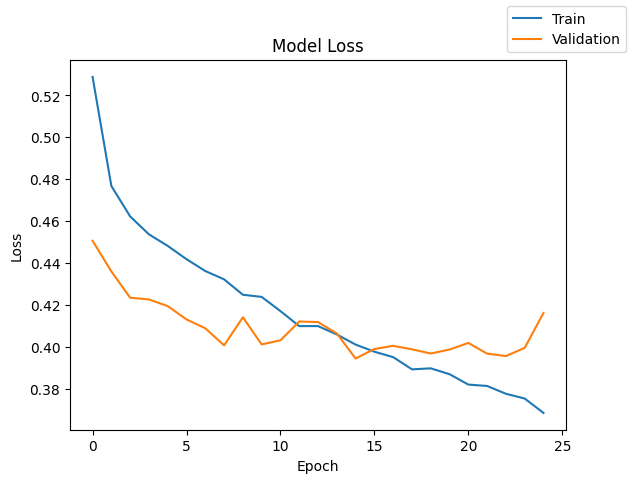

```python
plot(history, "loss")
```

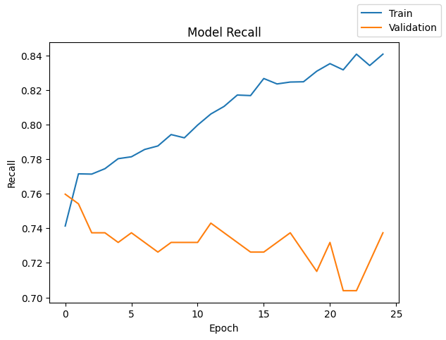

```python
plot(history,'recall')
```

```python
results.loc[5]=['2','[128,64]','[relu,relu]',epochs,batch_size,'Adam','[0.2,0.2]','Yes',(end-start),history.history["loss"][-1],history.history["val_loss"][-1],history.history["recall"][-1],history.history["val_recall"][-1]]
```

```python
results
```

|  | # hidden layers | # neurons - hidden layer | activation function - hidden layer | # epochs | batch size | optimizer | Dropout | SMOTE | time(secs) | Train_loss | Valid_loss | Train_Recall | Valid_Recall |
| --- | --- | --- | --- | --- | --- | --- | --- | --- | --- | --- | --- | --- | --- |
| 0 | 2 | [128,64] | [relu,relu] | 25 | 32 | SGD | - | - | 218.909014 | 0.343030 | 0.309187 | 0.448829 | 0.463687 |
| 1 | 2 | [128,64] | [relu,relu] | 25 | 32 | Adam | - | - | 246.185711 | 0.295605 | 0.295582 | 0.549938 | 0.541899 |
| 2 | 2 | [128,64] | [relu,relu] | 25 | 32 | Adam | [0.2,0.2] | - | 391.044503 | 0.321105 | 0.290420 | 0.495068 | 0.525140 |
| 3 | 2 | [128,64] | [relu,relu] | 25 | 32 | SGD | - | Yes | 248.838486 | 0.430218 | 0.419026 | 0.788962 | 0.737430 |
| 4 | 2 | [128,64] | [relu,relu] | 25 | 32 | Adam | - | Yes | 452.003888 | 0.264345 | 0.471866 | 0.900596 | 0.631285 |
| 5 | 2 | [128,64] | [relu,relu] | 25 | 32 | Adam | [0.2,0.2] | Yes | 474.656341 | 0.368626 | 0.416295 | 0.840859 | 0.737430 |

- Applying SMOTE and dropout resulted in a model with high recall and reduced overfitting compared to the Adam model with SMOTE but without dropout.
- Training time is higher than the Adam model with SMOTE but without dropout.

## Model Performance Comparison and Final Model Selection

```python
# Print performance summary for all the models, with recall diff
results['recall_diff'] = results['Train_Recall'] - results['Valid_Recall']
results
```

|  | # hidden layers | # neurons - hidden layer | activation function - hidden layer | # epochs | batch size | optimizer | Dropout | SMOTE | time(secs) | Train_loss | Valid_loss | Train_Recall | Valid_Recall | recall_diff |
| --- | --- | --- | --- | --- | --- | --- | --- | --- | --- | --- | --- | --- | --- | --- |
| 0 | 2 | [128,64] | [relu,relu] | 25 | 32 | SGD | - | - | 218.909014 | 0.343030 | 0.309187 | 0.448829 | 0.463687 | -0.014859 |
| 1 | 2 | [128,64] | [relu,relu] | 25 | 32 | Adam | - | - | 246.185711 | 0.295605 | 0.295582 | 0.549938 | 0.541899 | 0.008039 |
| 2 | 2 | [128,64] | [relu,relu] | 25 | 32 | Adam | [0.2,0.2] | - | 391.044503 | 0.321105 | 0.290420 | 0.495068 | 0.525140 | -0.030072 |
| 3 | 2 | [128,64] | [relu,relu] | 25 | 32 | SGD | - | Yes | 248.838486 | 0.430218 | 0.419026 | 0.788962 | 0.737430 | 0.051532 |
| 4 | 2 | [128,64] | [relu,relu] | 25 | 32 | Adam | - | Yes | 452.003888 | 0.264345 | 0.471866 | 0.900596 | 0.631285 | 0.269311 |
| 5 | 2 | [128,64] | [relu,relu] | 25 | 32 | Adam | [0.2,0.2] | Yes | 474.656341 | 0.368626 | 0.416295 | 0.840859 | 0.737430 | 0.103429 |

**Final Model Selection**

- Model 4 (SGD with SMOTE) and Model 6 (Adam with SMOTE and Dropout) have best validation recall. Let's compare both the models to finalize the model selection.
  - Model 4 and Model 6 has the same validation recall (0.737).
  - Model 4 has significantly less overfitting (0.052) compared to Model 6 (0.103).
  - Model 4 has a considerably shorter training time (249 seconds) than Model 6 (475 seconds).
- We'll go ahead with model 4 (SGD with SMOTE) as our final model.

### Final Model

```python
# clears the current Keras session, resetting all layers and models previously created, freeing up memory and resources.
tf.keras.backend.clear_session()
```

```python
#Initializing the neural network
model = Sequential()
model.add(Dense(128,activation="relu",input_dim=x_train.shape[1]))
model.add(Dense(64,activation="relu"))
model.add(Dense(1,activation="sigmoid"))
```

```python
model.summary()
```

```
Model: "sequential"
```

```
┏━━━━━━━━━━━━━━━━━━━━━━━━━━━━━━━━━━━━━━┳━━━━━━━━━━━━━━━━━━━━━━━━━━━━━┳━━━━━━━━━━━━━━━━━┓
┃ Layer (type)                         ┃ Output Shape                ┃         Param # ┃
┡━━━━━━━━━━━━━━━━━━━━━━━━━━━━━━━━━━━━━━╇━━━━━━━━━━━━━━━━━━━━━━━━━━━━━╇━━━━━━━━━━━━━━━━━┩
│ dense (Dense)                        │ (None, 128)                 │           1,536 │
├──────────────────────────────────────┼─────────────────────────────┼─────────────────┤
│ dense_1 (Dense)                      │ (None, 64)                  │           8,256 │
├──────────────────────────────────────┼─────────────────────────────┼─────────────────┤
│ dense_2 (Dense)                      │ (None, 1)                   │              65 │
└──────────────────────────────────────┴─────────────────────────────┴─────────────────┘
```

```
 Total params: 9,857 (38.50 KB)
```

```
 Trainable params: 9,857 (38.50 KB)
```

```
 Non-trainable params: 0 (0.00 B)
```

```python
optimizer = keras.optimizers.SGD()    # defining SGD as the optimizer to be used
model.compile(loss="binary_crossentropy", optimizer=optimizer, metrics=metrics,run_eagerly=True)
```

```python
start = time.time()
history = model.fit(x_train_over, y_train_over, validation_data=(x_test,y_test) , batch_size=batch_size, epochs=epochs)
end=time.time()
```

```
399/399 ━━━━━━━━━━━━━━━━━━━━ 10s 24ms/step - loss: 0.6605 - recall: 0.5227 - val_loss: 0.6028 - val_recall: 0.7288
399/399 ━━━━━━━━━━━━━━━━━━━━ 9s 22ms/step - loss: 0.5883 - recall: 0.7227 - val_loss: 0.5611 - val_recall: 0.7458
399/399 ━━━━━━━━━━━━━━━━━━━━ 10s 22ms/step - loss: 0.5532 - recall: 0.7441 - val_loss: 0.5363 - val_recall: 0.7712
399/399 ━━━━━━━━━━━━━━━━━━━━ 9s 23ms/step - loss: 0.5286 - recall: 0.7615 - val_loss: 0.5167 - val_recall: 0.7754
399/399 ━━━━━━━━━━━━━━━━━━━━ 9s 23ms/step - loss: 0.5078 - recall: 0.7732 - val_loss: 0.5007 - val_recall: 0.7797
399/399 ━━━━━━━━━━━━━━━━━━━━ 10s 23ms/step - loss: 0.4914 - recall: 0.7725 - val_loss: 0.4885 - val_recall: 0.7754
399/399 ━━━━━━━━━━━━━━━━━━━━ 9s 21ms/step - loss: 0.4796 - recall: 0.7761 - val_loss: 0.4803 - val_recall: 0.7924
399/399 ━━━━━━━━━━━━━━━━━━━━ 11s 22ms/step - loss: 0.4712 - recall: 0.7770 - val_loss: 0.4740 - val_recall: 0.7924
399/399 ━━━━━━━━━━━━━━━━━━━━ 14s 35ms/step - loss: 0.4653 - recall: 0.7808 - val_loss: 0.4696 - val_recall: 0.7924
399/399 ━━━━━━━━━━━━━━━━━━━━ 9s 22ms/step - loss: 0.4609 - recall: 0.7830 - val_loss: 0.4657 - val_recall: 0.7924
399/399 ━━━━━━━━━━━━━━━━━━━━ 9s 23ms/step - loss: 0.4575 - recall: 0.7820 - val_loss: 0.4625 - val_recall: 0.7839
399/399 ━━━━━━━━━━━━━━━━━━━━ 9s 23ms/step - loss: 0.4546 - recall: 0.7817 - val_loss: 0.4600 - val_recall: 0.7754
399/399 ━━━━━━━━━━━━━━━━━━━━ 10s 23ms/step - loss: 0.4521 - recall: 0.7825 - val_loss: 0.4574 - val_recall: 0.7754
399/399 ━━━━━━━━━━━━━━━━━━━━ 10s 22ms/step - loss: 0.4499 - recall: 0.7826 - val_loss: 0.4552 - val_recall: 0.7754
399/399 ━━━━━━━━━━━━━━━━━━━━ 10s 21ms/step - loss: 0.4477 - recall: 0.7821 - val_loss: 0.4535 - val_recall: 0.7754
399/399 ━━━━━━━━━━━━━━━━━━━━ 10s 22ms/step - loss: 0.4458 - recall: 0.7829 - val_loss: 0.4519 - val_recall: 0.7712
399/399 ━━━━━━━━━━━━━━━━━━━━ 13s 32ms/step - loss: 0.4439 - recall: 0.7834 - val_loss: 0.4503 - val_recall: 0.7669
399/399 ━━━━━━━━━━━━━━━━━━━━ 14s 36ms/step - loss: 0.4422 - recall: 0.7846 - val_loss: 0.4489 - val_recall: 0.7669
399/399 ━━━━━━━━━━━━━━━━━━━━ 15s 23ms/step - loss: 0.4404 - recall: 0.7847 - val_loss: 0.4479 - val_recall: 0.7669
399/399 ━━━━━━━━━━━━━━━━━━━━ 14s 33ms/step - loss: 0.4388 - recall: 0.7862 - val_loss: 0.4469 - val_recall: 0.7669
399/399 ━━━━━━━━━━━━━━━━━━━━ 10s 26ms/step - loss: 0.4372 - recall: 0.7855 - val_loss: 0.4458 - val_recall: 0.7542
399/399 ━━━━━━━━━━━━━━━━━━━━ 24s 35ms/step - loss: 0.4356 - recall: 0.7862 - val_loss: 0.4451 - val_recall: 0.7542
399/399 ━━━━━━━━━━━━━━━━━━━━ 10s 25ms/step - loss: 0.4341 - recall: 0.7853 - val_loss: 0.4443 - val_recall: 0.7542
399/399 ━━━━━━━━━━━━━━━━━━━━ 9s 24ms/step - loss: 0.4326 - recall: 0.7864 - val_loss: 0.4437 - val_recall: 0.7542
399/399 ━━━━━━━━━━━━━━━━━━━━ 12s 29ms/step - loss: 0.4312 - recall: 0.7886 - val_loss: 0.4432 - val_recall: 0.7500
```

```python
train_perf = model_performance(model,x_train,y_train)
print("Train performance")
pd.DataFrame(train_perf)
```

```
250/250 ━━━━━━━━━━━━━━━━━━━━ 1s 4ms/step
Train performance
```

|  | Accuracy | Recall | Precision | F1 |
| --- | --- | --- | --- | --- |
| 0 | 0.796125 | 0.768187 | 0.498201 | 0.604414 |

```python
valid_perf = model_performance(model,x_val,y_val)
print("Validation data performance")
pd.DataFrame(valid_perf)
```

```
32/32 ━━━━━━━━━━━━━━━━━━━━ 0s 3ms/step
Validation data performance
```

|  | Accuracy | Recall | Precision | F1 |
| --- | --- | --- | --- | --- |
| 0 | 0.809 | 0.731844 | 0.478102 | 0.578366 |

```python
test_perf = model_performance(model,x_test,y_test)
print("Test performance")
pd.DataFrame(test_perf)
```

```
32/32 ━━━━━━━━━━━━━━━━━━━━ 0s 3ms/step
Test performance
```

|  | Accuracy | Recall | Precision | F1 |
| --- | --- | --- | --- | --- |
| 0 | 0.796 | 0.75 | 0.549689 | 0.634409 |

**Model evaluation on the test data**

```
32/32 ━━━━━━━━━━━━━━━━━━━━ 0s 3ms/step
              precision    recall  f1-score   support

         0.0       0.91      0.81      0.86       764
         1.0       0.55      0.75      0.63       236

    accuracy                           0.80      1000
   macro avg       0.73      0.78      0.75      1000
weighted avg       0.83      0.80      0.81      1000
```

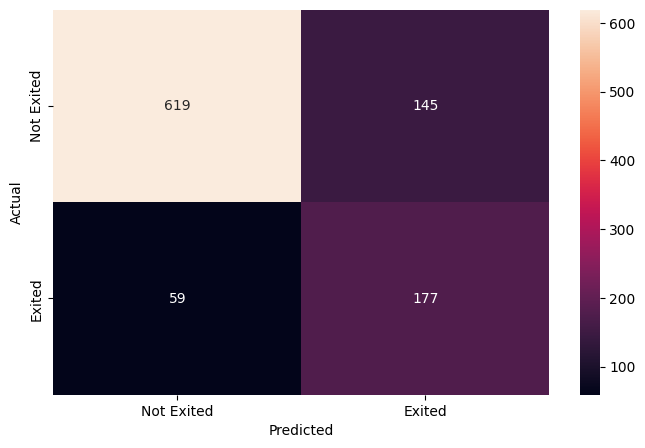

```python
test_pred = np.round(model.predict(x_test))

print(classification_report(y_test, test_pred))
cm = confusion_matrix(y_test, test_pred)
plt.figure(figsize=(8,5))
sns.heatmap(cm, annot=True,  fmt='.0f',xticklabels=['Not Exited', 'Exited'], yticklabels=['Not Exited', 'Exited'])
plt.ylabel('Actual')
plt.xlabel('Predicted')
plt.show()
```

- The model identifies 75% of all actual churners in the test data.
- The precision is lower indicating the model generates a significant number of false positives. This is acceptable given the priority for higher recall.
- The recall is consistently high across all three datasets (training, validation, and test). This demonstrates the model's high ability to idnetify customers who are likely to churn.
- The model prioritizes identifying as many potential churners as possible, even if it means some customers who won't churn are also flagged. This is reflected in the trade-off between precision and recall.
- The model generalizes reasonably well to unseen data, as evidenced by the similar performance metrics across the validation and test sets.
- The F1-score, which balances precision and recall, is moderately high, indicating a good overall performance.

## Actionable Insights and Business Recommendations

- **Actionable Insights:**
  - `Churn Probability:` The model provides a churn probability score for each customer, indicating their likelihood of leaving.
  - `Prioritized Retention:` Focus retention efforts on customers with the highest churn probabilities.
  - `Targeted Strategies:` Segment customers by churn risk and customize retention strategies for each group.
- **Business Recommendations:**
  - `Customized engagement for older customers:` Implement targeted programs to improve satisfaction and loyalty among older customers.
  - `Incentivize longer tenure:` Introduce loyalty rewards and benefits for customers who stay with the bank longer.
  - `Regional Focus:` Investigate the reasons behind Germany's high churn rate and implement region-specific strategies.
  - `Enhance female customer experience:` Understand the specific needs and pain points of female customers and improve services accordingly.
  - `Improve engagement for inactive customers:` Proactively reach out to inactive members with personalized offers and support.
  - `High-balance customer focus:` Understand the needs of high-balance customers and offer exclusive services or benefits.

Power Ahead